# visualization

Do Won Kim

2024-03-20

# 1 Scatter Plot

> Ro’ee: I think it would be useful at some point to create a scatter plot with WTA in round 1 in the x-axis and round 2 in the y-axis (and also just report the correlation). It’s a bit surprising that so many people provided a different answer, we should figure out if this is related to the question wording.

## 1.1 Plot 1.

- 14 cases removed (over $100)

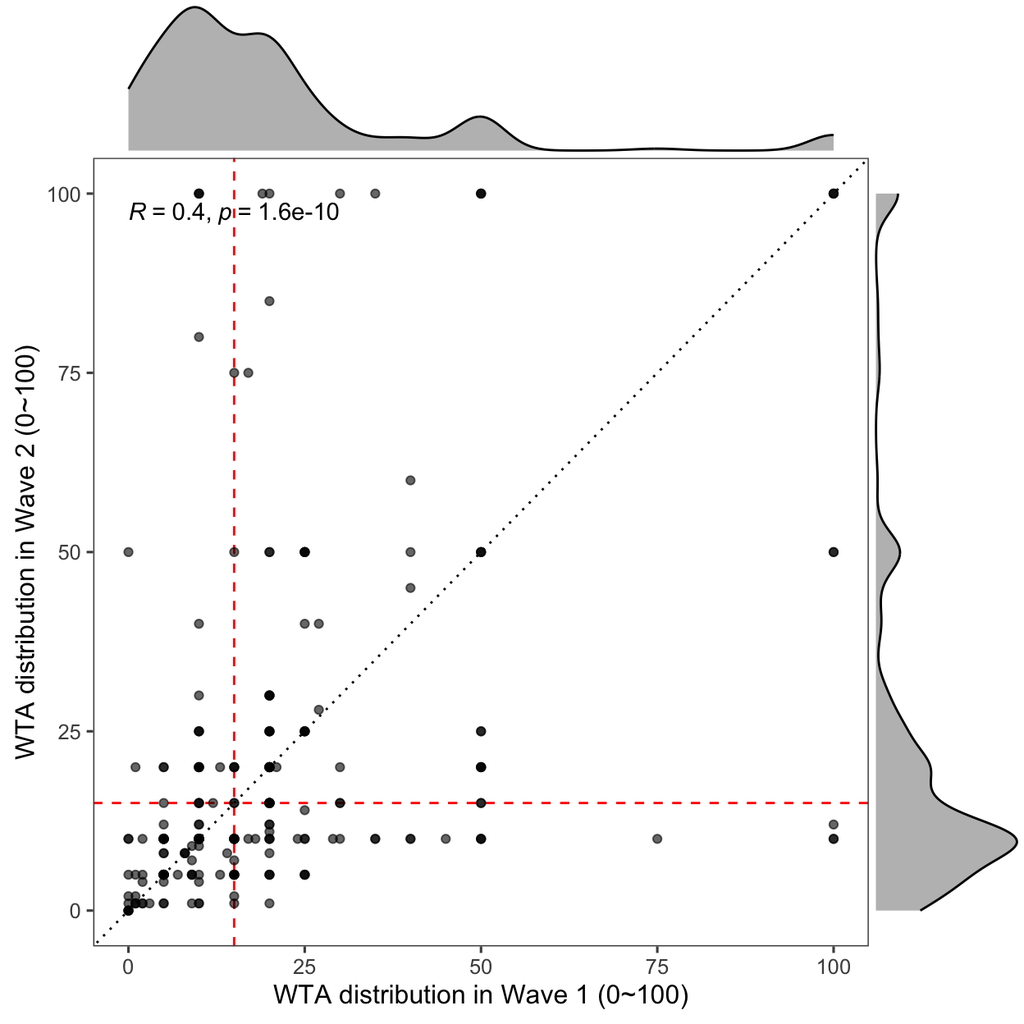

```r
library(tidyverse)
library(ggplot2)
library(DT)
library(haven)
library(ggpubr)
library(cowplot)
library(ggthemes)
library(readr)
library(ggExtra)
library(scales)
wta_df <- read_csv("wta/wta_df.csv", col_types = cols(userid = col_character(),
                                                      wta_w1 = col_integer(),
                                                      wta_w2 = col_integer(),
                                                      w2_compre1 = col_integer(),
                                                      w2_compre2 = col_integer()))


plot0 <- ggplot(wta_df, mapping = aes(wta_w1, wta_w2)) +
  geom_abline(intercept = 0, slope = 1, lty = 3, color = 'black') +
  geom_hline(yintercept = 15, lty = 2, color = 'red') +
  geom_vline(xintercept = 15, lty = 2, color = 'red') +
  geom_point(alpha=0.6) +
  stat_cor(method = 'pearson') +
  xlim(c(0, 100)) +
  ylim(c(0, 100)) +
  theme_few() +
  theme(legend.position = 'bottom') +
  xlab('WTA distribution in Wave 1 (0~100)') +
  ylab('WTA distribution in Wave 2 (0~100)')

ggMarginal(plot0, fill='gray')
```

## 1.2 Plot 2.

- Group by WTA group assigned in Wave 1
  - `assigned_wta_w1`: In Wave 1, what condition was the user assigned to
    - `scale_within`: user chose a number within 0~30 scale
    - `scale_over30`: user chose ‘over 30’ and then put the WTA amount
    - `open-ended`: user assigned to open-ended version (as in Wave 2)

Among those who got open-ended ver. in Wave 1,

- `always-over15`: 33 (28.4%)
- `always-under15`: 47 (40.5%)
- `favorable-shift`: 20 (17.2%)
- `unfavorable-shift`: 16 (13.8%)

cf) Among those who got scale ver. in Wave 1,

- `always-over15`: 53 (40.8%)
- `always-under15`: 35 (26.9%)
- `favorable-shift`: 32 (24.6%)
- `unfavorable-shift`: 10 (7.69%)

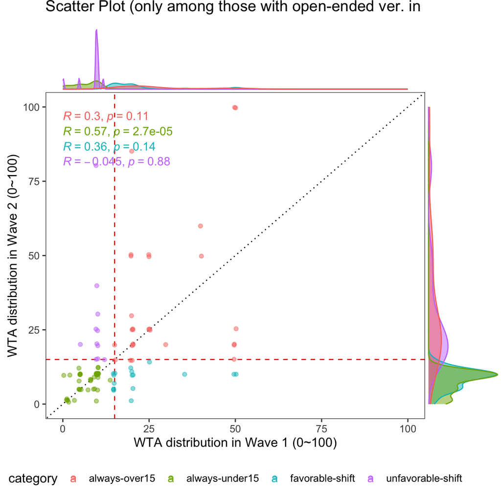

```r
wta_df |>
  filter(assigned_wta_w1=='open-ended') |>
    mutate(
    category = ifelse(
      wta_w1 < 15 & wta_w2 < 15, "always-under15",
      ifelse(wta_w1 >= 15 & wta_w2 >= 15, "always-over15",
             ifelse(wta_w1 >=15 & wta_w2 < 15, "favorable-shift", "unfavorable-shift")))
    ) |>
    filter(!is.na(wta_w1)) -> op_wta_df

#
randomized_group <- read_csv("randomized_group.csv",
    col_types = cols(id = col_skip(), user_id = col_character(),
        session_start = col_datetime(format = "%Y-%m-%d %H:%M:%S")))

names(randomized_group)[1] = "userid"

op_wta_df |>
  merge(randomized_group, by = c("userid"), all.x = T) -> op_wta_df2

op_wta_df2 |>
  mutate(
    version = ifelse(session_start < "2024-03-01", "ver1", "ver2")
  ) -> op_wta_df2

plot1_op <- ggplot(op_wta_df, mapping = aes(wta_w1, wta_w2, color=category)) +
  geom_abline(intercept = 0, slope = 1, lty = 3, color = 'black') +
  geom_hline(yintercept = 15, lty = 2, color = 'red') +
  geom_vline(xintercept = 15, lty = 2, color = 'red') +
  geom_jitter(alpha=0.5) +
  stat_cor(method = 'pearson') +
  xlim(c(0, 100)) +
  ylim(c(0, 100)) +
  theme_few() +
  theme(legend.position = 'bottom') +
  xlab('WTA distribution in Wave 1 (0~100)') +
  ylab('WTA distribution in Wave 2 (0~100)') +
  ggtitle('Scatter Plot (only among those with open-ended ver. in Wave 1)')


ggMarginal(plot1_op, groupColour = TRUE, groupFill = TRUE)
```

## 1.3 Plot 3.

- Group by `category` based on WTA $
  - `always-under15`: user chose below $15 in both waves
  - `always-over15`: user chose $15 or over in both waves
  - `favorable-shift`: user chose $15 or over in wave 1 but shifted below $15 in wave 2
  - `unfavorable-shift`: user chose below $15 in wave 1 but shifted $15 or over in wave 2

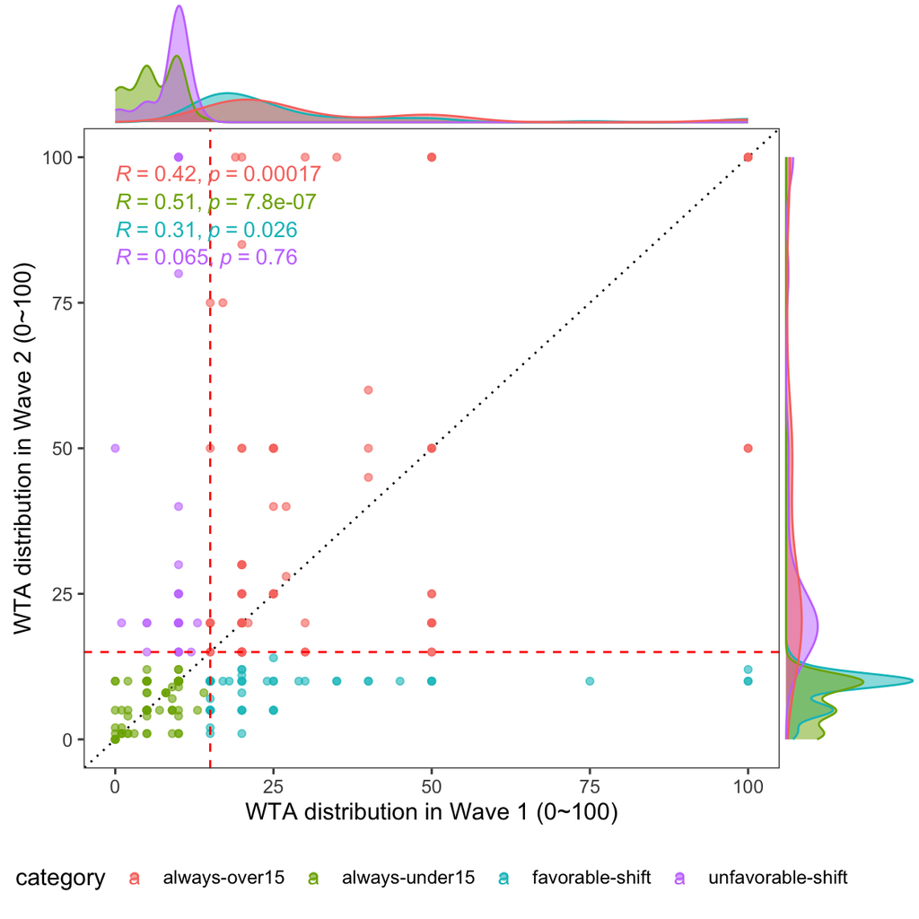

```r
wta_df |>
  mutate(
    category = ifelse(
      wta_w1 < 15 & wta_w2 < 15, "always-under15",
      ifelse(wta_w1 >= 15 & wta_w2 >= 15, "always-over15",
             ifelse(wta_w1 >=15 & wta_w2 < 15, "favorable-shift", "unfavorable-shift")))
    ) |>
    filter(!is.na(wta_w1)) -> wta_df


ggplot(wta_df, mapping = aes(wta_w1, wta_w2, col=category)) +
  geom_abline(intercept = 0, slope = 1, lty = 3, color = 'black') +
  geom_point(alpha=0.6) +
  geom_hline(yintercept = 15, lty = 2, color = 'red') +
  geom_vline(xintercept = 15, lty = 2, color = 'red') +
  theme_few() +
  xlim(c(0, 100)) +
  ylim(c(0, 100)) +
  stat_cor(method = 'pearson') +
  xlab('WTA distribution in Wave 1 (0~100)') +
  ylab('WTA distribution in Wave 2 (0~100)') +
  theme(legend.position='bottom') -> plot2

ggMarginal(plot2, groupColour = TRUE, groupFill = TRUE)
```

## 1.4 Plot 4.

- log10 scales for both x, y axes
- no filtering out those WTA > $100

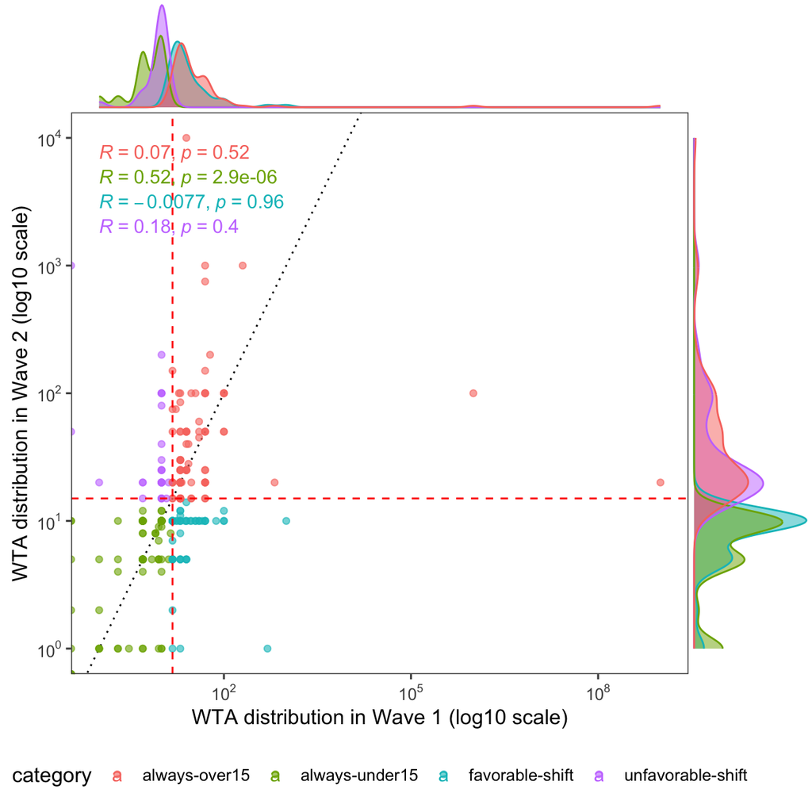

```r
ggplot(wta_df, mapping = aes(wta_w1, wta_w2, col=category)) +
  geom_abline(intercept = 0, slope = 1, lty = 3, color = 'black') +
  geom_point(alpha=0.6) +
  geom_hline(yintercept = 15, lty = 2, color = 'red') +
  geom_vline(xintercept = 15, lty = 2, color = 'red') +
  scale_x_log10(labels = label_log(digits = 2)) +
  scale_y_log10(labels = label_log(digits = 2)) +
  theme_few() +
  stat_cor(method = 'pearson') +
  xlab('WTA distribution in Wave 1 (log10 scale)') +
  ylab('WTA distribution in Wave 2 (log10 scale)') +
  theme(legend.position='bottom') -> plot3

ggMarginal(plot3, groupColour = TRUE, groupFill = TRUE)
```

# 2 Engagements & Exposure

```r
library(tidyverse)
library(DT)
library(haven)
library(readr)

# load raw data
df_w1 <- readRDS("~/Downloads/2023-095b_files/2023-095a_client_wave-1.rds")
df_w1_supp <- readRDS("~/Downloads/2023-095b_files/2023-095a_client_wave-1_supp.rds")
df_w2 <- readRDS("~/Downloads/2023-095b_files/2023-095b_client_wave-2.rds")


# bind wave 1 data + filter only Progress == 100
df_w1 = rbind(df_w1, df_w1_supp)
df_w1 |>
  select(-user_id) |>
  filter(Progress==100) -> df_w1

# invited users list (for merge)
Users_to_invite_Wave2 <- read_csv("Users_to_invite_Wave2.csv",
    col_types = cols(user_id = col_character()))
Users_to_invite_Wave2 |>
  select(user_id) |>
  mutate(userid = user_id) -> for_merge

# merged with invited user list
df_w2 |>
  merge(for_merge, by='userid') -> w2_users

# merged with invited user list
w2_users |>
  select(userid, user_id) |>
  merge(df_w1, by='userid') -> w1_users

# drop randomized_group == 'drop' from wave 2
w2_users |>
  filter(randomized_group != 'drop') |>
  filter(randomized_group != 'muting_treatment2_drop') |>
  select(userid, randomized_group) -> wave2_data
# 134 users without drop

# muted_accounts
muted_accounts <- read_csv("muted_accounts.csv",
    col_types = cols(user_id = col_character(),
        target_user_id = col_character()))

# exposure data
pre_hometimeline <- read_csv("pre_hometimeline.csv",
    col_types = cols(user_id = col_character(),
        target_user_id = col_character()))

pre_hometimeline |>
  rename(type = match_type) |>
  mutate(tag = "pre_hometimeline") -> pre_hometimeline

post_hometimeline <- read_csv("post_hometimeline.csv",
    col_types = cols(user_id = col_character(),
        target_user_id = col_character()))

post_hometimeline |>
  mutate(tag = "post_hometimeline") -> post_hometimeline

# engagement data
pre_engagement <- read_csv("pre_engagement.csv",
    col_types = cols(user_id = col_character(),
        target_user_id = col_character()))

pre_engagement |>
  mutate(tag = "pre_engagement") -> pre_engagement

post_engagement <- read_csv("post_engagement.csv",
    col_types = cols(user_id = col_character(),
        target_user_id = col_character()))

post_engagement |>
  mutate(tag = "post_engagement") -> post_engagement

# truncated list
updated_inventory <- read_csv("updated_inventory.csv",
    col_types = cols_only(target_user_id = col_character()))
reduced_inventory = updated_inventory[c(1:489),]
#reduced_inventory <- read_csv("reduced_inventory.csv",
#    col_types = cols_only(target_user_id = col_character()))
```

```r
wave2_data |> rename(user_id = userid) |> merge(pre_engagement, by='user_id') -> this_1
wave2_data |> rename(user_id = userid) |> merge(post_engagement, by='user_id') -> this_2
wave2_data |> rename(user_id = userid) |> merge(pre_hometimeline, by='user_id') -> this_3
wave2_data |> rename(user_id = userid) |> merge(post_hometimeline, by='user_id') -> this_4
rbind(this_1, this_2, this_3, this_4) -> test
```

```r
reduced_inventory |> mutate(reduced = "yes") -> reduced_inventory
muted_accounts |> mutate(muted = "yes") -> muted_accounts

test |>
  merge(muted_accounts, by = c('user_id', 'target_user_id'), all.x = TRUE) |>
  mutate(
    muted = ifelse(is.na(muted), "no", muted)
  ) |>
  merge(reduced_inventory, by='target_user_id', all.x = TRUE) |>
  mutate(
    reduced = ifelse(is.na(reduced), "no", reduced)
  ) |>
  relocate(c(user_id, randomized_group)) -> this_is_full_data
```

```r
# count_engagement.csv
count_engagement <- read_csv("count_engagement.csv",
    col_types = cols(user_id = col_character()))

this_is_full_data |>
  merge(count_engagement, by=c('user_id','tag') ,all.x=TRUE) -> this_is_final_data
```

## 2.1 Data Description

`this_is_final_data`

(user level)

- `user_id`: Participants’ Twitter IDs
- `randomized_group`: Randomized group - `media_literacy`, `muting_treatment1/2`, `control`
- `tag`:
  - `pre_hometimeline/engagement`: home timeline (reverse chronological) or engagement data collected before treatment (wave 2)
  - `post_hometimeline/engagement`: home timeline or engagement data collected after treatment (wave 2) ~ till Mar 14
    - I collected post-treatment data on Mar 14, which is 2 weeks after the start of Wave 2. Thus, the data contains maximum 2 weeks ~ minimum 1 week post-treatment.
- `count`: Number of tweets collected

(user-LQ account dyad level)

- `target_user_id`: LQ accounts’ Twitter IDs (found in home timeline or engagement data)
- `type`: Type of tweets related to LQ sources
  - `direct`: Direct tweets mentioning LQ sources
  - `replied`: Reply tweets to LQ sources
  - `retweeted`: Any retweets of LQ tweets
  - `quoted`: Any quote tweets of LQ tweets
- `muted` : Whether the LQ source is muted (“yes”) or not (“no”)
- `reduced` : Whether the LQ source is included in the reduced list (“yes”) or not (“no”)

```r
this_is_final_data |>
  relocate(user_id, randomized_group, tag, count) |>
  datatable(filter='top')
```

|  | user_id | randomized_group | tag | count | target_user_id | type | muted | reduced |
| --- | --- | --- | --- | --- | --- | --- | --- | --- |
| 1 | 1040039078270517248 | media_literacy | post_hometimeline | 399 | 1446932149148344320 | direct | yes | yes |
| 2 | 1040039078270517248 | media_literacy | post_hometimeline | 399 | 1446932149148344320 | direct | yes | yes |
| 3 | 1040039078270517248 | media_literacy | post_hometimeline | 399 | 1446932149148344320 | direct | yes | yes |
| 4 | 1040039078270517248 | media_literacy | post_hometimeline | 399 | 1446932149148344320 | direct | yes | yes |
| 5 | 1040039078270517248 | media_literacy | pre_hometimeline | 396 | 1446932149148344320 | direct | yes | yes |
| 6 | 1040039078270517248 | media_literacy | pre_hometimeline | 396 | 1446932149148344320 | direct | yes | yes |
| 7 | 1040039078270517248 | media_literacy | pre_hometimeline | 396 | 1446932149148344320 | direct | yes | yes |
| 8 | 1040039078270517248 | media_literacy | pre_hometimeline | 396 | 1446932149148344320 | direct | yes | yes |
| 9 | 1040039078270517248 | media_literacy | pre_hometimeline | 396 | 1446932149148344320 | direct | yes | yes |
| 10 | 1062796950431506432 | muting_treatment1 | pre_hometimeline | 383 | 916114570833551360 | quoted | no | no |

[output cut: 8889 more lines]

## 2.2 **Clarification of the task**

1. Post-treatment engagement/exposure between control (those unmuted from the onset) vs. muting group (for 30% unmuted):
   - to check there are no differences between these two groups, and
   - whether they are still engaging with LQ sources that are not muted
2. Add the same plot as #1 but with pre-treatment engagement/exposure
   - to check that those unmuted have not changed behavior after the treatment (compared to pre-treatment period)

```r
library(Rmisc)
# Muting 30% filtered
this_is_final_data |>
  mutate(
    group = ifelse(randomized_group=="media_literacy", "MediaLiteracy",
                   ifelse(randomized_group=='control', "Control", "Muting")
  )) |>
  mutate(flag = ifelse(
    group == "Control", "include", # Control group all included
    ifelse( # For Muting group, only include cases where muted == "no"
      group == "Muting" & muted == "no", "include", "drop"
    )
  )) |>
  filter(flag == "include") |> select(!flag) -> test_again

test_again |>
  select(user_id, tag, randomized_group, count) |>
  group_by(user_id, tag) |>
  count() |> ungroup() -> test_for_unmuted30

# test_for_unmuted30 - if there are no categories (tag), freq == 0
test_for_unmuted30 |>
  select(user_id, tag, freq) |>
  pivot_wider(names_from=tag, values_from=freq) |>
  mutate_if(is.numeric , replace_na, replace = 0) |>
  relocate(user_id,
           pre_hometimeline, post_hometimeline,
           pre_engagement, post_engagement) -> test_for_unmuted30_wider

test_for_unmuted30_wider |>
  select(user_id, pre_hometimeline:post_engagement) |>
  pivot_longer(cols=pre_hometimeline:post_engagement,
               names_to = "tag",
               values_to = "n") -> test_for_unmuted30_longer
test_again |>
  select(user_id, tag, count) |>
  unique() |>
  merge(test_for_unmuted30_longer, by=c("user_id", "tag"), all=TRUE) |>
  mutate_if(is.numeric , replace_na, replace = 0) -> test_for_unmuted30_longer2

test_again |> select(user_id, tag, randomized_group) |> unique() -> for_merge_unmuted30_1
for_merge_unmuted30_1 |>
  select(user_id, randomized_group) |>
  unique() -> for_merge_unmuted30_2

test_for_unmuted30_longer2 |>
  merge(for_merge_unmuted30_1, by = c('user_id', 'tag'), all.x = T) |>
  select(user_id, tag, count, n) |>
  merge(for_merge_unmuted30_2, by = "user_id") |>
  mutate(group = ifelse(randomized_group == "control" |
                          randomized_group == "media_literacy",
                        "Control", "Muting")) -> test_for_unmuted30_longer3

# backup
df_plot_unmuted = test_for_unmuted30_longer3
```

## 2.3 Plot 1. Post-treatment engagement

Post-treatment engagement between `control` vs. `muting` (for unmuted accounts)

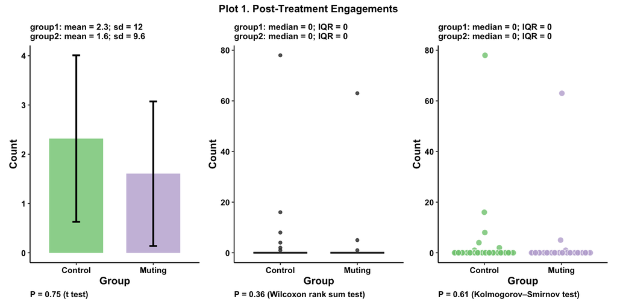

```r
library(tidyverse)
library(ggbeeswarm) # to make jitter plots
library(RColorBrewer) # for the colors
library(patchwork)

df_plot_unmuted |>
  mutate(rate = (n/count)*100) |>
  mutate_if(is.numeric , replace_na, replace = 0) |>
  mutate(rate = round(rate,1)) |>
  filter(tag == 'post_engagement') |> # tag == 'post_engagement' filter
  select(user_id, group, n, rate) -> df_post_engagement

df_post_engagement |>
  filter(group == "Control") |>
  select(n) |>
  as.vector() |>
  unlist() |>
  as.integer() -> group1

df_post_engagement |>
  filter(group == "Muting") |>
  select(n) |>
  as.vector() |>
  unlist() |>
  as.integer() -> group2

df_post_engagement |>
  ggplot(aes(x = group, y = n)) +
  geom_bar(stat = "summary", fun = mean, width = 0.7, alpha = 0.8, aes(fill = group)) +
  stat_summary(geom = "errorbar", fun.data = "mean_se", width = 0.1, linewidth = 1) +
  scale_fill_manual(values = brewer.pal(8, "Accent")[1:2]) +
  labs(x = "Group",
       y = "Count",
       caption = paste0("P = ",
                        signif(t.test(group1, group2)$p.value, 2),
                        " (t test)")) +
  theme_classic() +
  theme(
    text = element_text(size = 12, face = "bold", color = "black"),
    axis.text = element_text(color = "black"),
    legend.position = "none",
    plot.title = element_text(size = 10),
    plot.caption = element_text(hjust = 0)
  ) +
  ggtitle(
    paste0(
      "group1: mean = ", signif(mean(group1), 2),
      "; sd = ", signif(sd(group1), 2), "\n",
      "group2: mean = ", signif(mean(group2), 2),
      "; sd = ", signif(sd(group2), 2)
    )) -> bar_post_engagement

df_post_engagement |>
  ggplot(aes(x = group, y = n)) +
  geom_boxplot(width = 0.7, alpha = 0.8, aes(fill = group)) +
  scale_fill_manual(values = brewer.pal(8, "Accent")[1:2]) +
  labs(x = "Group",
       y = "Count",
       caption = paste0("P = ",
                        signif(wilcox.test(group1, group2)$p.value, 2),
                        " (Wilcoxon rank sum test)")) +
  theme_classic() +
  theme(
    text = element_text(size = 12, face = "bold", color = "black"),
    axis.text = element_text(color = "black"),
    legend.position = "none",
    plot.title = element_text(size = 10),
    plot.caption = element_text(hjust = 0)
  ) +
  ggtitle(
    paste0(
      "group1: median = ", signif(median(group1), 2),
      "; IQR = ", signif(IQR(group1), 2), "\n",
      "group2: median = ", signif(median(group2), 2),
      "; IQR = ", signif(IQR(group2), 2)
    )
  ) -> box_post_engagement

df_post_engagement |>
  ggplot(aes(x = group, y = n)) +
  ggbeeswarm::geom_quasirandom(
    shape = 21, color = "white",
    alpha = 0.8, size = 3,
    aes(fill = group)
  ) +
  scale_fill_manual(values = brewer.pal(8, "Accent")[1:2]) +
  labs(x = "Group",
       y = "Count",
        caption = paste0("P = ",
                        signif(ks.test(group1, group2)$p.value, 2),
                        " (Kolmogorov–Smirnov test)")) +
  theme_classic() +
  theme(
    text = element_text(size = 12, face = "bold", color = "black"),
    axis.text = element_text(color = "black"),
    legend.position = "none",
    plot.title = element_text(size = 10),
    plot.caption = element_text(hjust = 0)
  ) +
  ggtitle(
    paste0(
      "group1: median = ", signif(median(group1), 2),
      "; IQR = ", signif(IQR(group1), 2), "\n",
      "group2: median = ", signif(median(group2), 2),
      "; IQR = ", signif(IQR(group2), 2)
    )
  ) -> dot_post_engagement


wrap_plots(
  bar_post_engagement, box_post_engagement, dot_post_engagement, nrow = 1
)  + plot_annotation('Plot 1. Post-Treatment Engagements',
                        theme=theme(plot.title=element_text(size = 12,
                                                            face = "bold",
                                                            color = "black",
                                                            hjust=0.5)))
```

```r
ggsave("../Results/plot1_unmuted.png", height = 5, width = 10)
```

### 2.3.1 **Description (1)**

Hence, Plot 1 allows us to compare the post-treatment engagements with unmuted LQ accounts between `Control` and `Muting` groups.

For most participants, we see low levels of engagements with LQ accounts with a few outliers (active ones). Given this highly skewed distribution, and to be careful with comparison, I drew the same quantities but with different ways of visualizing them.

1. (left) Bar plot
   - Comparison: mean
   - Error bars indicate SEs of the mean
   - t-test statistics (p-value presented)
2. (middle) Box plot
   - Comparison: median
   - Wilcoxon rank sum test (nonparametric)
3. (right) Dot plot
   - Comparison: distribution
   - K-S test (nonparametric)

## 2.4 Plot 2. Post-treatment exposure

Post-treatment exposure between `control` vs. `muting` (for unmuted accounts)

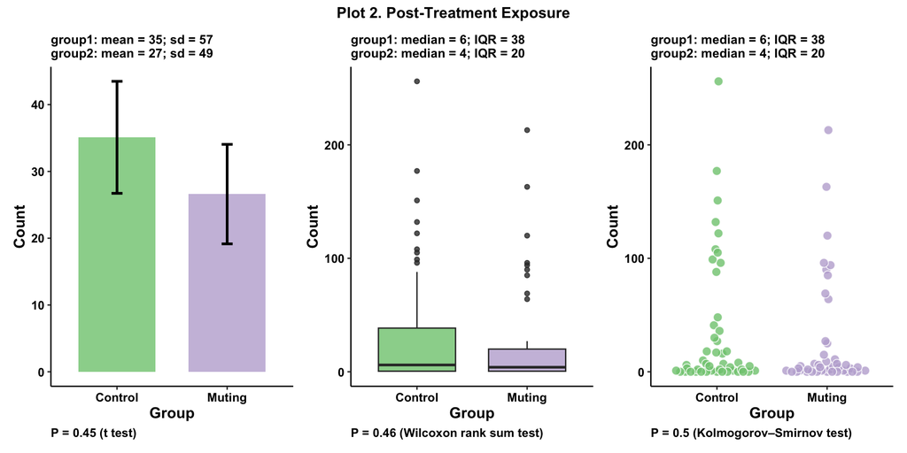

```r
# Use df_plot_unmuted
df_plot_unmuted |>
  filter(tag == "post_hometimeline") |> # tag == 'post_hometimeline' filter
  select(user_id, group, n) -> df_post_hometimeline

df_post_hometimeline |>
  filter(group == "Control") |>
  select(n) |>
  as.vector() |>
  unlist() |>
  as.integer() -> group1

df_post_hometimeline |>
  filter(group == "Muting") |>
  select(n) |>
  as.vector() |>
  unlist() |>
  as.integer() -> group2

df_post_hometimeline |>
  ggplot(aes(x = group, y = n)) +
  geom_bar(stat = "summary", fun = mean, width = 0.7, alpha = 0.8, aes(fill = group)) +
  stat_summary(geom = "errorbar", fun.data = "mean_se", width = 0.1, linewidth = 1) +
  scale_fill_manual(values = brewer.pal(8, "Accent")[1:2]) +
  labs(x = "Group",
       y = "Count",
       caption = paste0("P = ",
                        signif(t.test(group1, group2)$p.value, 2),
                        " (t test)")) +
  theme_classic() +
  theme(
    text = element_text(size = 12, face = "bold", color = "black"),
    axis.text = element_text(color = "black"),
    legend.position = "none",
    plot.title = element_text(size = 10),
    plot.caption = element_text(hjust = 0)
  ) +
  ggtitle(
    paste0(
      "group1: mean = ", signif(mean(group1), 2),
      "; sd = ", signif(sd(group1), 2), "\n",
      "group2: mean = ", signif(mean(group2), 2),
      "; sd = ", signif(sd(group2), 2)
    )) -> bar_post_hometimeline

df_post_hometimeline |>
  ggplot(aes(x = group, y = n)) +
  geom_boxplot(width = 0.7, alpha = 0.8, aes(fill = group)) +
  scale_fill_manual(values = brewer.pal(8, "Accent")[1:2]) +
  labs(x = "Group",
       y = "Count",
       caption = paste0("P = ",
                        signif(wilcox.test(group1, group2)$p.value, 2),
                        " (Wilcoxon rank sum test)")) +
  theme_classic() +
  theme(
    text = element_text(size = 12, face = "bold", color = "black"),
    axis.text = element_text(color = "black"),
    legend.position = "none",
    plot.title = element_text(size = 10),
    plot.caption = element_text(hjust = 0)
  ) +
  ggtitle(
    paste0(
      "group1: median = ", signif(median(group1), 2),
      "; IQR = ", signif(IQR(group1), 2), "\n",
      "group2: median = ", signif(median(group2), 2),
      "; IQR = ", signif(IQR(group2), 2)
    )
  ) -> box_post_hometimeline

df_post_hometimeline |>
  ggplot(aes(x = group, y = n)) +
  ggbeeswarm::geom_quasirandom(
    shape = 21, color = "white",
    alpha = 0.8, size = 3,
    aes(fill = group)
  ) +
  scale_fill_manual(values = brewer.pal(8, "Accent")[1:2]) +
  labs(x = "Group",
       y = "Count",
        caption = paste0("P = ",
                        signif(ks.test(group1, group2)$p.value, 2),
                        " (Kolmogorov–Smirnov test)")) +
  theme_classic() +
  theme(
    text = element_text(size = 12, face = "bold", color = "black"),
    axis.text = element_text(color = "black"),
    legend.position = "none",
    plot.title = element_text(size = 10),
    plot.caption = element_text(hjust = 0)
  ) +
  ggtitle(
    paste0(
      "group1: median = ", signif(median(group1), 2),
      "; IQR = ", signif(IQR(group1), 2), "\n",
      "group2: median = ", signif(median(group2), 2),
      "; IQR = ", signif(IQR(group2), 2)
    )
  ) -> dot_post_hometimeline


wrap_plots(
  bar_post_hometimeline, box_post_hometimeline, dot_post_hometimeline, nrow = 1
)  -> plot2

plot2 + plot_annotation('Plot 2. Post-Treatment Exposure',
                        theme=theme(plot.title=element_text(size = 12,
                                                            face = "bold",
                                                            color = "black",
                                                            hjust=0.5)))
```

```r
ggsave("../Results/plot2_unmuted.png", height = 5, width = 10)
```

### 2.4.1 **Description (2)**

The y-axis (`Count`) indicates the number of LQ tweets found in one’s home timeline (=exposure).

Hence, Plot 2 allows us to compare the post-treatment exposures to unmuted LQ accounts between `Control` and `Muting` groups.

For more descriptions of each panel, please refer to the above descriptions. And for Plots 3 and 4, I replicated Plots 1 and 2 with pre-treatment data.

## 2.5 Plot 3. Pre-treatment engagement

Pre-treatment engagement between `control` vs. `muting` (for unmuted accounts)

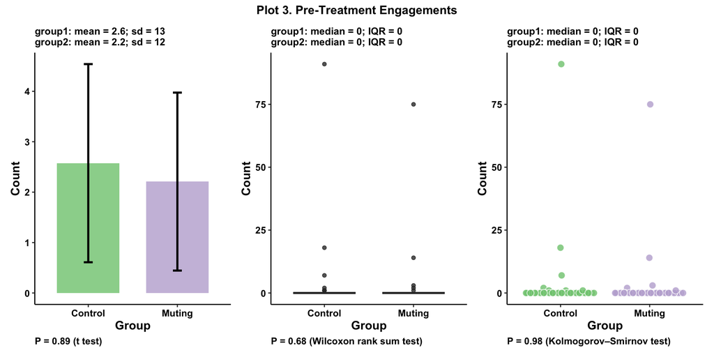

```r
df_plot_unmuted |>
  filter(tag == "pre_engagement") |>
  select(user_id, group, n) -> df_pre_engagement

df_pre_engagement |>
  filter(group == "Control") |>
  select(n) |>
  as.vector() |>
  unlist() |>
  as.integer() -> group1

df_pre_engagement |>
  filter(group == "Muting") |>
  select(n) |>
  as.vector() |>
  unlist() |>
  as.integer() -> group2

df_pre_engagement |>
  ggplot(aes(x = group, y = n)) +
  geom_bar(stat = "summary", fun = mean, width = 0.7, alpha = 0.8, aes(fill = group)) +
  stat_summary(geom = "errorbar", fun.data = "mean_se", width = 0.1, linewidth = 1) +
  scale_fill_manual(values = brewer.pal(8, "Accent")[1:2]) +
  labs(x = "Group",
       y = "Count",
       caption = paste0("P = ",
                        signif(t.test(group1, group2)$p.value, 2),
                        " (t test)")) +
  theme_classic() +
  theme(
    text = element_text(size = 12, face = "bold", color = "black"),
    axis.text = element_text(color = "black"),
    legend.position = "none",
    plot.title = element_text(size = 10),
    plot.caption = element_text(hjust = 0)
  ) +
  ggtitle(
    paste0(
      "group1: mean = ", signif(mean(group1), 2),
      "; sd = ", signif(sd(group1), 2), "\n",
      "group2: mean = ", signif(mean(group2), 2),
      "; sd = ", signif(sd(group2), 2)
    )) -> bar_pre_engagement

df_pre_engagement |>
  ggplot(aes(x = group, y = n)) +
  geom_boxplot(width = 0.7, alpha = 0.8, aes(fill = group)) +
  scale_fill_manual(values = brewer.pal(8, "Accent")[1:2]) +
  labs(x = "Group",
       y = "Count",
       caption = paste0("P = ",
                        signif(wilcox.test(group1, group2)$p.value, 2),
                        " (Wilcoxon rank sum test)")) +
  theme_classic() +
  theme(
    text = element_text(size = 12, face = "bold", color = "black"),
    axis.text = element_text(color = "black"),
    legend.position = "none",
    plot.title = element_text(size = 10),
    plot.caption = element_text(hjust = 0)
  ) +
  ggtitle(
    paste0(
      "group1: median = ", signif(median(group1), 2),
      "; IQR = ", signif(IQR(group1), 2), "\n",
      "group2: median = ", signif(median(group2), 2),
      "; IQR = ", signif(IQR(group2), 2)
    )
  ) -> box_pre_engagement

df_pre_engagement |>
  ggplot(aes(x = group, y = n)) +
  ggbeeswarm::geom_quasirandom(
    shape = 21, color = "white",
    alpha = 0.8, size = 3,
    aes(fill = group)
  ) +
  scale_fill_manual(values = brewer.pal(8, "Accent")[1:2]) +
  labs(x = "Group",
       y = "Count",
        caption = paste0("P = ",
                        signif(ks.test(group1, group2)$p.value, 2),
                        " (Kolmogorov–Smirnov test)")) +
  theme_classic() +
  theme(
    text = element_text(size = 12, face = "bold", color = "black"),
    axis.text = element_text(color = "black"),
    legend.position = "none",
    plot.title = element_text(size = 10),
    plot.caption = element_text(hjust = 0)
  ) +
  ggtitle(
    paste0(
      "group1: median = ", signif(median(group1), 2),
      "; IQR = ", signif(IQR(group1), 2), "\n",
      "group2: median = ", signif(median(group2), 2),
      "; IQR = ", signif(IQR(group2), 2)
    )
  ) -> dot_pre_engagement


wrap_plots(
  bar_pre_engagement, box_pre_engagement, dot_pre_engagement, nrow = 1
)  -> plot3

plot3 + plot_annotation('Plot 3. Pre-Treatment Engagements',
                        theme=theme(plot.title=element_text(size = 12,
                                                            face = "bold",
                                                            color = "black",
                                                            hjust=0.5)))
```

```r
ggsave("../Results/plot3_unmuted.png", height = 5, width = 10)
```

## 2.6 Plot 4. Pre-treatment exposure

Pre-treatment exposure between `control` vs. `muting` (for unmuted accounts)

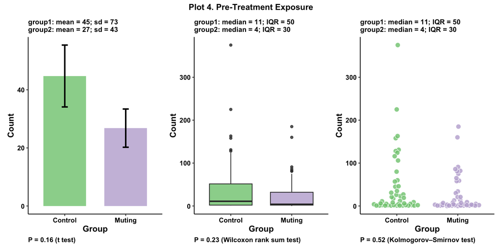

```r
# Use df_plot_unmuted
df_plot_unmuted |>
  filter(tag == "pre_hometimeline") |> # tag == 'post_hometimeline' filter
  select(user_id, group, n) -> df_pre_hometimeline

df_pre_hometimeline |>
  filter(group == "Control") |>
  select(n) |>
  as.vector() |>
  unlist() |>
  as.integer() -> group1

df_pre_hometimeline |>
  filter(group == "Muting") |>
  select(n) |>
  as.vector() |>
  unlist() |>
  as.integer() -> group2

df_pre_hometimeline |>
  ggplot(aes(x = group, y = n)) +
  geom_bar(stat = "summary", fun = mean, width = 0.7, alpha = 0.8, aes(fill = group)) +
  stat_summary(geom = "errorbar", fun.data = "mean_se", width = 0.1, linewidth = 1) +
  scale_fill_manual(values = brewer.pal(8, "Accent")[1:2]) +
  labs(x = "Group",
       y = "Count",
       caption = paste0("P = ",
                        signif(t.test(group1, group2)$p.value, 2),
                        " (t test)")) +
  theme_classic() +
  theme(
    text = element_text(size = 12, face = "bold", color = "black"),
    axis.text = element_text(color = "black"),
    legend.position = "none",
    plot.title = element_text(size = 10),
    plot.caption = element_text(hjust = 0)
  ) +
  ggtitle(
    paste0(
      "group1: mean = ", signif(mean(group1), 2),
      "; sd = ", signif(sd(group1), 2), "\n",
      "group2: mean = ", signif(mean(group2), 2),
      "; sd = ", signif(sd(group2), 2)
    )) -> bar_pre_hometimeline

df_pre_hometimeline |>
  ggplot(aes(x = group, y = n)) +
  geom_boxplot(width = 0.7, alpha = 0.8, aes(fill = group)) +
  scale_fill_manual(values = brewer.pal(8, "Accent")[1:2]) +
  labs(x = "Group",
       y = "Count",
       caption = paste0("P = ",
                        signif(wilcox.test(group1, group2)$p.value, 2),
                        " (Wilcoxon rank sum test)")) +
  theme_classic() +
  theme(
    text = element_text(size = 12, face = "bold", color = "black"),
    axis.text = element_text(color = "black"),
    legend.position = "none",
    plot.title = element_text(size = 10),
    plot.caption = element_text(hjust = 0)
  ) +
  ggtitle(
    paste0(
      "group1: median = ", signif(median(group1), 2),
      "; IQR = ", signif(IQR(group1), 2), "\n",
      "group2: median = ", signif(median(group2), 2),
      "; IQR = ", signif(IQR(group2), 2)
    )
  ) -> box_pre_hometimeline

df_pre_hometimeline |>
  ggplot(aes(x = group, y = n)) +
  ggbeeswarm::geom_quasirandom(
    shape = 21, color = "white",
    alpha = 0.8, size = 3,
    aes(fill = group)
  ) +
  scale_fill_manual(values = brewer.pal(8, "Accent")[1:2]) +
  labs(x = "Group",
       y = "Count",
        caption = paste0("P = ",
                        signif(ks.test(group1, group2)$p.value, 2),
                        " (Kolmogorov–Smirnov test)")) +
  theme_classic() +
  theme(
    text = element_text(size = 12, face = "bold", color = "black"),
    axis.text = element_text(color = "black"),
    legend.position = "none",
    plot.title = element_text(size = 10),
    plot.caption = element_text(hjust = 0)
  ) +
  ggtitle(
    paste0(
      "group1: median = ", signif(median(group1), 2),
      "; IQR = ", signif(IQR(group1), 2), "\n",
      "group2: median = ", signif(median(group2), 2),
      "; IQR = ", signif(IQR(group2), 2)
    )
  ) -> dot_pre_hometimeline


wrap_plots(
  bar_pre_hometimeline, box_pre_hometimeline, dot_pre_hometimeline, nrow = 1
)  -> plot4

plot4 + plot_annotation('Plot 4. Pre-Treatment Exposure',
                        theme=theme(plot.title=element_text(size = 12,
                                                            face = "bold",
                                                            color = "black",
                                                            hjust=0.5)))
```

```r
ggsave("../Results/plot4_unmuted.png", height = 5, width = 10)
```

# 3 Note

1. Post-Treatment Engagements with LQ accounts that are “not muted” - From the truncated list (n=489), we chose 70% to mute. In this case, the rest of the 30% of this truncated list (n=146) would be LQ accounts ‘not muted’. - Instead, from Plot 1 ~ Plot 4, I used the full LQ list (not truncated); in this case, the LQ accounts ‘not muted’ includes 30% + those accounts that were cutoff due to truncation.
2. About data collection period
   - I collected post-treatment data on Mar 14, which is 2 weeks after the start of Wave 2. Thus, the post-treatment data contains maximum 2 weeks ~ minimum 1 week, while pre-treatment data contains maximum 4 weeks.
   - Although data collection time spans are different between pre- and post-treatment, we have maximum tweet cap both for engagement (max 300) and home timeline (max 400) and we don’t generally go over more than 2 weeks to hit the maximum cap.